# Visualization Quick Start

CVC 2015

## Glyphs and Data

In its original sense, in archeology, a glyph is a carved symbol.

## Data Glyph

The features of a data glyph encodes the value of variables.

See: *http://docs.ggplot2.org/current/*

## Data Glyph Properties: Aesthetics

Aesthetics are **visual properties** of a glyph.

- Aesthetics for points: location (x and y), shape, color, size, transparency

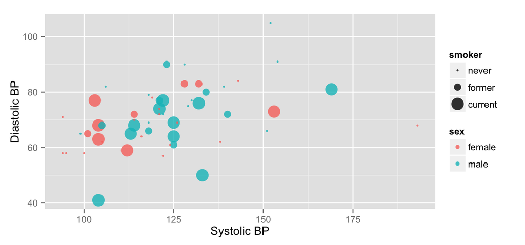

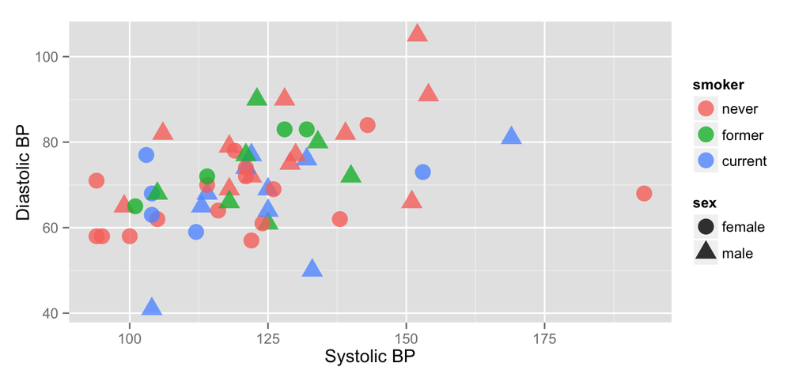

- Each glyph has its own set of aesthetics.

## Why "Aesthetic"?

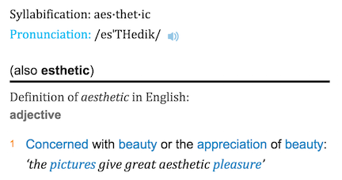

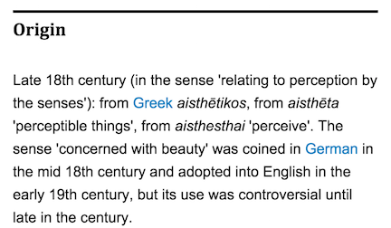

## Some Graphics Components

**glyph** : The basic graphical unit that represents one case. Other terms used include *mark* and *symbol*.

**aesthetic** : a visual property of a glyph such as position, size, shape, color, etc.

- may be **mapped** based on data values: `sex -> color`
- may be **set** to particular non-data related values: `color is black`

**scale** : A mapping that translates data values into aesthetics.

- example: male -> blue; female -> pink

**frame** : The position scale describing how data are mapped to x and y

**guide** : An indication for the human viewer of the scale. This allows the viewer to translate aesthetics back into data values.

- Examples: x- and y-axes, various sorts of legends

## Glyph-Ready Data

Glyph-ready data has this form:

- There is one row for each glyph to be drawn.
- The variables in that row are mapped to aesthetics of the glyph (including position)

**Glyph-ready data**

```
##   sbp dbp    sex  smoker
## 1 129  75   male   never
## 2 105  62 female   never
## 3 122  72   male   never
## 4 128  83 female  former
## 5 123  90   male  former
## 6 122  77   male current
```

**Mapping of data to aesthetics**

```
   sbp -> x
   dbp -> y
smoker -> color
   sex -> shape
```

Scales determine details of  
`data -> aesthetic` translation

## A few more elements

1. Facets – using x and y twice
2. Layers – building up to complex graphics
3. Stats – data transformations

## Facets – using x and y twice

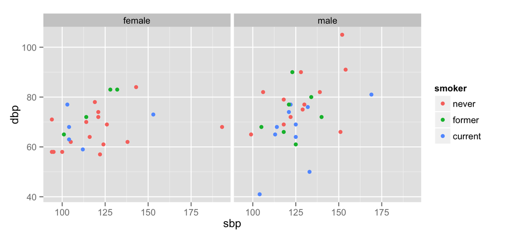

- x is determined by `sbp` and `sex`
- basically a separate frame for each `sex`

## Layers – building up complex plots

Each layer may have its own data, glyphs, aesthetic mapping, etc.

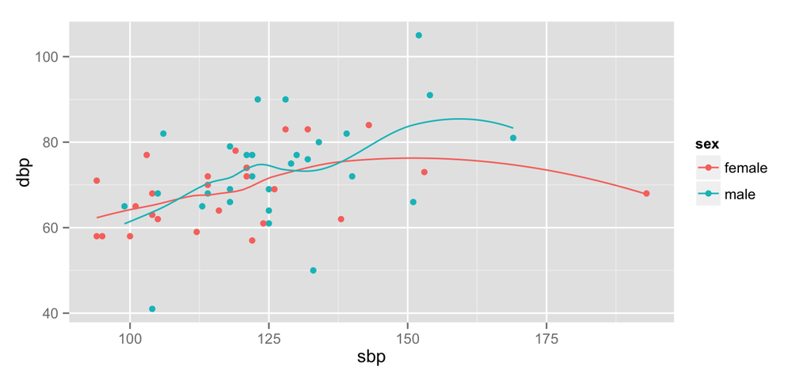

- one layer has points
- another layer has the curves

## Stats: Data Transformations

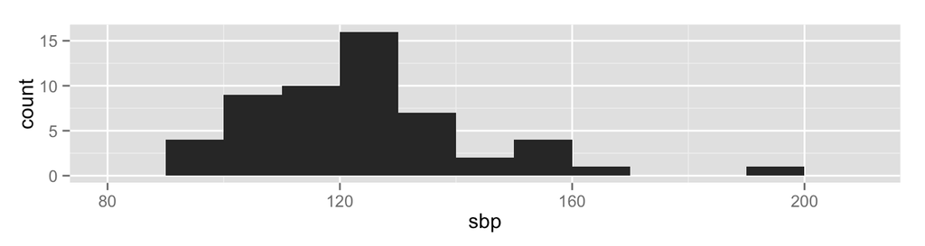

- What are the glyphs, aesthetics, etc. for this plot?
- How is the data for this plot related to the "raw" data?

```
##   sbp dbp    sex smoker
## 1 129  75   male  never
## 2 105  62 female  never
## 3 122  72   male  never
## 4 128  83 female former
```

## What's Next

1. **Eye-training**
   - recognize and describe glyphs, aesthetics, scales, etc.
   - identify data required for a plot
2. **Data wrangling**
   - get data into glyph-ready format (`dplyr`, `tidyr`)
3. **Graphics construction**
   - describe data, glyphs, aesthetics, etc. to R (`lattice`, `ggplot2`)

## Exercises

## Start out with a GUI

Map variables to aesthetics with `mplot()`